# Module 6. Interpretation, contrasts and prediction

Slides

# Reading coefficients

## In an interaction model, a “main effect” is a simple effect

| term | time from 0 | time from 12 |
| --- | --- | --- |
| (Intercept) | 145.01 | 144.61 |
| month | -0.03 | -0.03 |
| armSP | 0.31 | -5.57 |
| armEP | -0.76 | -9.45 |
| month:armSP | -0.49 | -0.49 |
| month:armEP | -0.72 | -0.72 |

- `armSP` = difference **at time zero**. Centre time at 12 and it becomes the difference at month 12.
- Same model, same log-likelihood; different questions.

## In the primary model, the month-12 interaction is the difference in change

| term | meaning | estimate |
| --- | --- | --- |
| armSP | SP - UC at baseline | 1.04 |
| visit_f12 | change to month 12 in UC only | -1.33 |
| visit_f12:armSP | difference in change, SP - UC | -5.38 |
| visit_f12:armEP | difference in change, EP - UC | -8.97 |

## Centre covariates so the intercept means something

|  | (Intercept) | visit_f12:armEP |
| --- | --- | --- |
| centred | 148.8 | -9.02 |
| raw | 122.2 | -9.02 |

- Raw: intercept for a man aged 0 with BMI 0.
- Centred (age 60, BMI 29): a sensible baseline value. Treatment terms unchanged.

## Try it

Workbook exercise 1: read the coefficients of the linear-time model with time centred at 6 months.

# Estimated marginal means and contrasts

## EMMs are model-based cell means for every arm and visit

```r
emm <- emmeans(m_prim, ~ visit_f * arm)
```

| arm | visit_f | emmean | SE | lower.CL | upper.CL |
| --- | --- | --- | --- | --- | --- |
| UC | 0 | 146.2 | 1.2 | 143.8 | 148.6 |
| UC | 6 | 144.6 | 1.2 | 142.1 | 147.0 |
| UC | 12 | 144.9 | 1.3 | 142.3 | 147.4 |
| SP | 0 | 147.2 | 1.2 | 144.8 | 149.7 |
| SP | 6 | 140.8 | 1.2 | 138.3 | 143.2 |
| SP | 12 | 140.5 | 1.3 | 138.0 | 143.1 |
| EP | 0 | 147.5 | 1.2 | 145.1 | 150.0 |
| EP | 6 | 136.9 | 1.2 | 134.5 | 139.4 |
| EP | 12 | 137.2 | 1.3 | 134.7 | 139.8 |

## EMMs are not observed means when dropout depends on the outcome

| arm | visit_f | observed | emmean | difference |
| --- | --- | --- | --- | --- |
| UC | 0 | 146.2 | 146.2 | -0.01 |
| UC | 12 | 144.3 | 144.9 | -0.53 |
| SP | 0 | 147.2 | 147.2 | -0.02 |
| SP | 12 | 139.6 | 140.5 | -0.97 |
| EP | 0 | 147.5 | 147.5 | 0.00 |
| EP | 12 | 136.6 | 137.2 | -0.66 |

## A contrast is a vector of weights over the 18 cells

```r
cells  <- expand.grid(visit_f = levels(walk$visit_f), arm = levels(walk$arm))
cell_w <- function(a, v) as.numeric(cells$arm == a & cells$visit_f == v)
chg    <- function(a, v = "12") cell_w(a, v) - cell_w(a, "0")
L <- list("SP - UC" = chg("SP") - chg("UC"),
          "EP - UC" = chg("EP") - chg("UC"),
          "EP - SP" = chg("EP") - chg("SP"))
contrast(emm, L)
```

```
#>  contrast estimate   SE  df t.ratio p.value
#>  SP - UC     -5.38 1.42 483  -3.782  0.0002
#>  EP - UC     -8.97 1.44 491  -6.243 <0.0001
#>  EP - SP     -3.59 1.43 484  -2.521  0.0120
#>
#> Degrees-of-freedom method: satterthwaite
```

## The primary estimates

| Contrast | Estimate (95% CI), mmHg | p | True value (simulated) |
| --- | --- | --- | --- |
| SP - UC | -5.4 (-8.2 to -2.6) | p < 0.001 | -4.6 |
| EP - UC | -9.0 (-11.8 to -6.1) | p < 0.001 | -8.1 |
| EP - SP | -3.6 (-6.4 to -0.8) | p = 0.012 | -3.5 |

## The interaction-contrast approach gives the whole profile

```r
ic <- contrast(emm, interaction = c(visit_f = "trt.vs.ctrl1",
                                    arm = "trt.vs.ctrl1"))
```

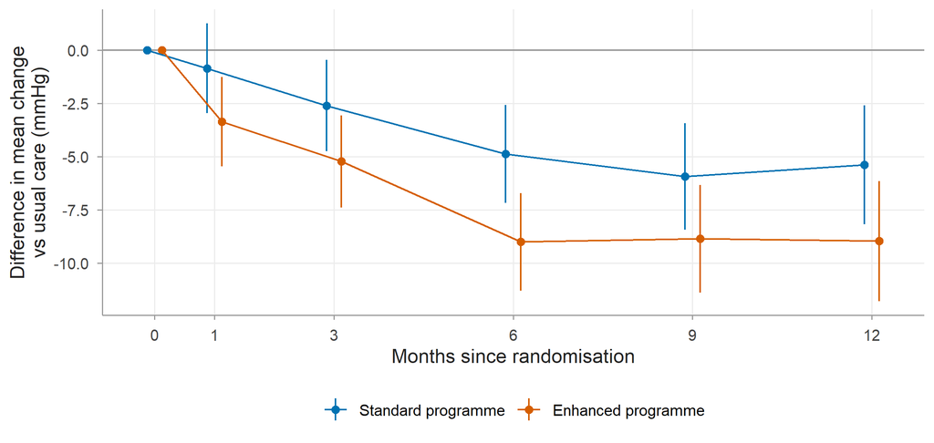

## Try it

Workbook exercises 2 and 3: EMMs, custom contrasts and the interaction-contrast approach.

# Multiplicity

## Define the family before adjusting

- **Primary family**: SP vs UC and EP vs UC at month 12 (a claim of success if either is significant).
- **Secondary**: EP vs SP; differences at months 1 to 9. Reported with unadjusted CIs, labelled.
- Options: Bonferroni, Holm, Dunnett (`adjust = "mvt"`), fixed sequence.

## Adjustment changes p-values and interval widths, not estimates

| adjustment | contrast | estimate | lower | upper | p |
| --- | --- | --- | --- | --- | --- |
| none | SP - UC | -5.377 | -8.170 | -2.584 | 2e-04 |
| none | EP - UC | -8.969 | -11.792 | -6.146 | 0e+00 |
| holm | SP - UC | -5.377 | -8.573 | -2.181 | 2e-04 |
| holm | EP - UC | -8.969 | -12.199 | -5.739 | 0e+00 |
| dunnett | SP - UC | -5.377 | -8.530 | -2.223 | 3e-04 |
| dunnett | EP - UC | -8.969 | -12.156 | -5.782 | 0e+00 |

## When not to adjust

- One prespecified primary comparison.
- Secondary estimates reported as estimates with CIs and clearly labelled.
- Visit-by-visit profiles that describe the shape of an effect.
- Model checks.

# Predictions

## Population-average vs subject-specific predictions

$$E(y_{ij}) = \mathbf{x}_{ij}^\top\boldsymbol\beta
\qquad
E(y_{ij}\mid\mathbf{b}_i) = \mathbf{x}_{ij}^\top\boldsymbol\beta + \mathbf{z}_{ij}^\top\mathbf{b}_i$$

```r
predict(m_prim, re.form = NA)   # population average (fixed effects only)
predict(m_prim)                  # subject specific (adds BLUPs)
```

- Identity link: averaging subject-specific predictions over $\mathbf{b}_i$ gives the population average.

## Subject-specific lines scatter around the population line

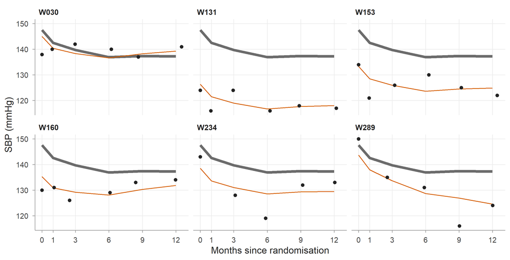

## Averages of `predict()` over observed rows reflect who stayed

| arm | observed | mean_subject_specific | population_average |
| --- | --- | --- | --- |
| UC | 144.3 | 144.3 | 144.9 |
| SP | 139.6 | 139.6 | 140.5 |
| EP | 136.6 | 136.6 | 137.2 |

- Over a complete grid of all participants the two agree to within 0.03 mmHg.

## Try it

Workbook exercise 4: population-average and subject-specific predictions.

# Confidence and prediction intervals

## A CI is about the mean; a PI is about an individual measurement

$$\text{new participant: } \operatorname{Var} = \mathbf{x}^\top\widehat{\operatorname{Var}}(\hat{\boldsymbol\beta})\mathbf{x} + \mathbf{z}^\top\hat G\mathbf{z} + \hat\sigma^2$$

| EP, month 12 | Width (mmHg) | Range |
| --- | --- | --- |
| 95% CI for the mean | 5.2 | 134.7 to 139.8 |
| 95% PI, new participant | 54.2 | 110.2 to 164.3 |

## Showing both on one axis makes the difference obvious

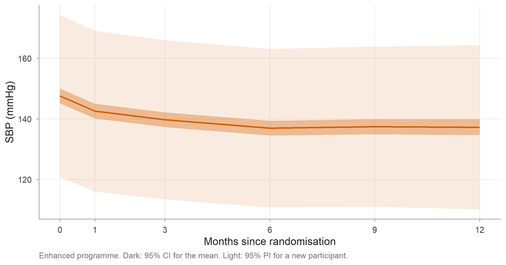

## Try it

Workbook exercise 5: analytic and simulated prediction intervals.

# Presenting results

## A good trajectory figure

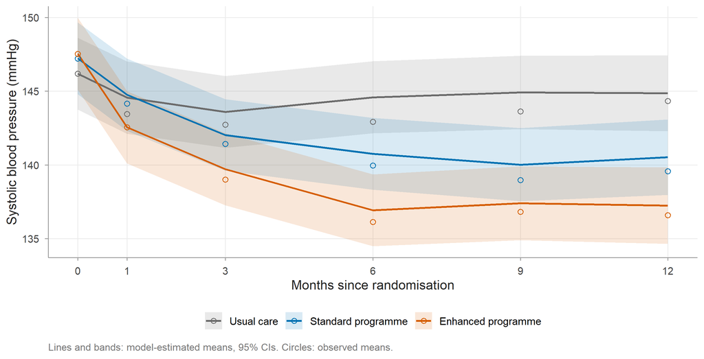

## A results table for the primary outcome

| Arm | Mean change (95% CI) | Difference vs UC (95% CI) | p |
| --- | --- | --- | --- |
| Usual care | -1.3 (-3.3 to 0.7) | Reference |  |
| Standard programme | -6.7 (-8.7 to -4.7) | -5.4 (-8.2 to -2.6) | p < 0.001 |
| Enhanced programme | -10.3 (-12.3 to -8.3) | -9.0 (-11.8 to -6.1) | p < 0.001 |

# Constrained baseline ADVANCED

## cLDA: one common baseline mean, justified by randomisation

```r
walk <- walk |>
  mutate(grp = ifelse(visit == 1, "base", paste(arm, visit_f, sep = "_")),
         grp = relevel(factor(grp), ref = "base"))
m_clda <- lmer(sbp ~ grp + (1 + month | id), data = walk, control = lmer_ctrl)
```

| contrast | cLDA | cLDA_SE | unconstrained | unconstrained_SE |
| --- | --- | --- | --- | --- |
| SP - UC | -5.09 | 1.34 | -5.38 | 1.42 |
| EP - UC | -8.60 | 1.35 | -8.97 | 1.44 |

## Summary

- Main effects in interaction models are simple effects; centring changes the question, not the model.
- Compute EMMs and explicit contrasts; the primary estimand is a difference in mean change.
- Adjust for multiplicity within a prespecified primary family only.
- Population-average and subject-specific predictions agree on average with an identity link.
- CIs describe means; PIs describe individuals and are much wider.
- Show model estimates with named uncertainty on honest axes.